# Visualisation Assignment Portfolio 3

Amanda Gulstad Pedersen

26-05-2025

I am, for the most part, following the coding from “Sentiment Analysis IPCC”.

### Loading the pdf

```r
got_text <- pdf_text(here("data", "got.pdf"))
```

### Some wrangling:

```r
got_df <- data.frame(got_text) %>%
  mutate(text_full = str_split(got_text, pattern = '\n')) %>%
  unnest(text_full) %>%
  mutate(text_full = str_trim(text_full))
```

### Get the tokens in tidy format

Changing the format from a whole sentence pr column to individual words in each column.

```r
got_tokens <- got_df %>%
  unnest_tokens(word, text_full)
```

Checking word count for the volume arranged in descending order:

```r
got_wc <- got_tokens %>%
  count(word) %>%
  arrange(-n)
got_wc
```

```
## # A tibble: 11,826 × 2
##    word      n
##    <chr> <int>
##  1 the   17988
##  2 and    8997
##  3 to     6640
##  4 a      6461
##  5 of     6200
##  6 he     5166
##  7 his    5161
##  8 was    3904
##  9 her    3659
## 10 you    3267
## # ℹ 11,816 more rows
```

### Removing stop words

Using the function anti_join to remove the stop words. The stop word list used here is a part of the tidytext package, containing fillerwords from the english language.

```r
got_stop <- got_tokens %>%
  anti_join(stop_words) %>%
  select(-got_text)
```

Checking the wordcount once again shows completely different words at the top of our count with the removal of 531 words.

```r
got_swc <- got_stop %>%
  count(word) %>%
  arrange(-n)

got_swc
```

```
## # A tibble: 11,295 × 2
##    word       n
##    <chr>  <int>
##  1 lord    1341
##  2 ser     1023
##  3 jon      787
##  4 ned      743
##  5 tyrion   591
##  6 eyes     567
##  7 hand     567
##  8 king     542
##  9 father   512
## 10 told     504
## # ℹ 11,285 more rows
```

After removing the numbers in the text, the wordcount is down another 86 “tokens”.

```r
got_no_numeric <- got_stop %>%
  filter(is.na(as.numeric(word)))

got_no_numeric %>%
  count(word) %>%
  arrange(-n)
```

```
## # A tibble: 11,209 × 2
##    word       n
##    <chr>  <int>
##  1 lord    1341
##  2 ser     1023
##  3 jon      787
##  4 ned      743
##  5 tyrion   591
##  6 eyes     567
##  7 hand     567
##  8 king     542
##  9 father   512
## 10 told     504
## # ℹ 11,199 more rows
```

### A word cloud for Game of Thrones

For the word cloud we are using the 100 most frequent words by first creating a new object for the words, then creating the cloud.

```r
got_top100 <- got_no_numeric %>%
  count(word) %>%
  arrange(-n) %>%
  head(100)
got_top100
```

```
## # A tibble: 100 × 2
##    word       n
##    <chr>  <int>
##  1 lord    1341
##  2 ser     1023
##  3 jon      787
##  4 ned      743
##  5 tyrion   591
##  6 eyes     567
##  7 hand     567
##  8 king     542
##  9 father   512
## 10 told     504
## # ℹ 90 more rows
```

```r
got_cloud <- ggplot(data = got_top100, aes(label = word, size = n, color = n)) +
  geom_text_wordcloud(shape = "diamond") +
  scale_size_area(max_size = 10) +
  scale_color_gradient(high ="#32CD32", low = "#023020")
  theme_bw()
```

[output not shown]

[output cut: 250 more lines]

[output not shown]

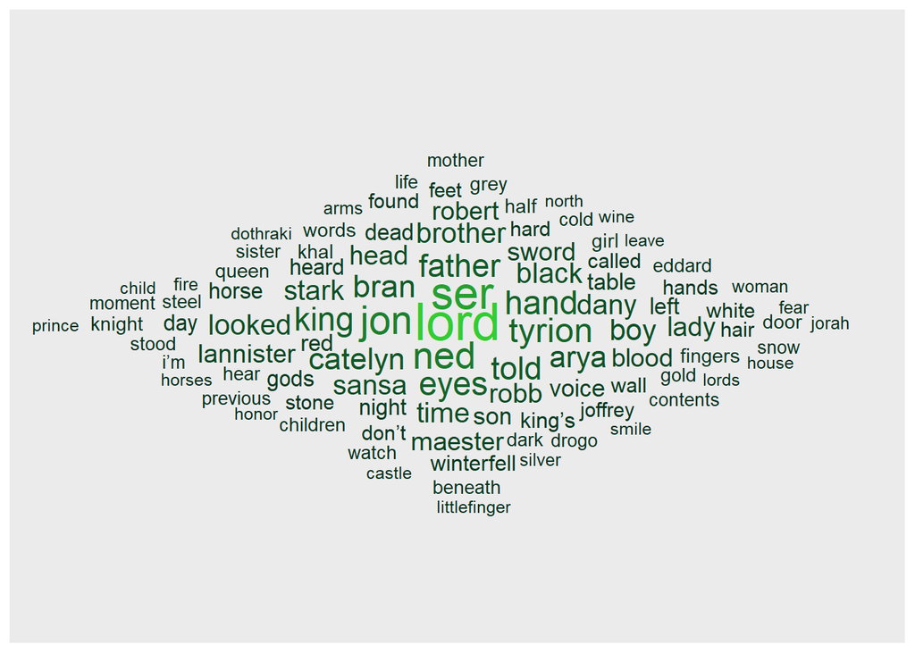

```r
got_cloud
```

A wordcloud is a useful tool, as it shows a (superficial) visual snapshot of a texts themes. This wordcloud shows that many of the most frequent words (“lord”, “ser”, “king”) are related to power-relations, which is in line with central themes found in the book.

### Sentiment analysis of A Game of Thrones

Loading the tree lexicons “afinn”, “nrc”, and “bing”:

```r
get_sentiments(lexicon = "afinn")
```

```
## # A tibble: 2,477 × 2
##    word       value
##    <chr>      <dbl>
##  1 abandon       -2
##  2 abandoned     -2
##  3 abandons      -2
##  4 abducted      -2
##  5 abduction     -2
##  6 abductions    -2
##  7 abhor         -3
##  8 abhorred      -3
##  9 abhorrent     -3
## 10 abhors        -3
## # ℹ 2,467 more rows
```

```r
get_sentiments(lexicon = "bing")
```

```
## # A tibble: 6,786 × 2
##    word        sentiment
##    <chr>       <chr>
##  1 2-faces     negative
##  2 abnormal    negative
##  3 abolish     negative
##  4 abominable  negative
##  5 abominably  negative
##  6 abominate   negative
##  7 abomination negative
##  8 abort       negative
##  9 aborted     negative
## 10 aborts      negative
## # ℹ 6,776 more rows
```

```r
get_sentiments(lexicon = "nrc")
```

```
## # A tibble: 13,872 × 2
##    word        sentiment
##    <chr>       <chr>
##  1 abacus      trust
##  2 abandon     fear
##  3 abandon     negative
##  4 abandon     sadness
##  5 abandoned   anger
##  6 abandoned   fear
##  7 abandoned   negative
##  8 abandoned   sadness
##  9 abandonment anger
## 10 abandonment fear
## # ℹ 13,862 more rows
```

### Sentiment analysis with afinn:

Using the function inner_join to combine the words from the AFINN lexicon with the GoT manuscript. The inner_join function only keeps the words that appear in BOTH, and everything else if excluded.

```r
got_afinn <- got_stop %>%
  inner_join(get_sentiments("afinn"))
got_afinn
```

```
## # A tibble: 13,058 × 2
##    word  value
##    <chr> <dbl>
##  1 fire     -2
##  2 dead     -3
##  3 dead     -3
##  4 smile     2
##  5 dead     -3
##  6 dead     -3
##  7 dead     -3
##  8 dead     -3
##  9 dead     -3
## 10 drag     -1
## # ℹ 13,048 more rows
```

The AFINN lexicon uses a scoring system rankring from -5 to +5. A visualisation can show the overall score of the manuscript, which is mostly negative accoring to AFINNs standarts.

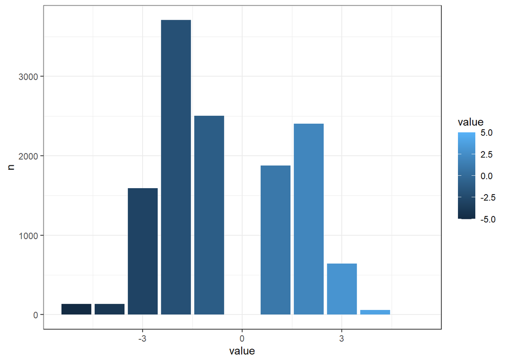

```r
got_afinn_hist <- got_afinn %>%
  count(value)

ggplot(data = got_afinn_hist, aes(x = value, y = n)) +
  geom_col(aes(fill = value)) +
  theme_bw()
```

## Investigate some of the words in a bit more depth:

Investigating the words with a +4 score by first creating an object only including these +4-words, then plotting them using ggplot.

```r
got_afinn4 <- got_afinn %>%
  filter(value == 4)
```

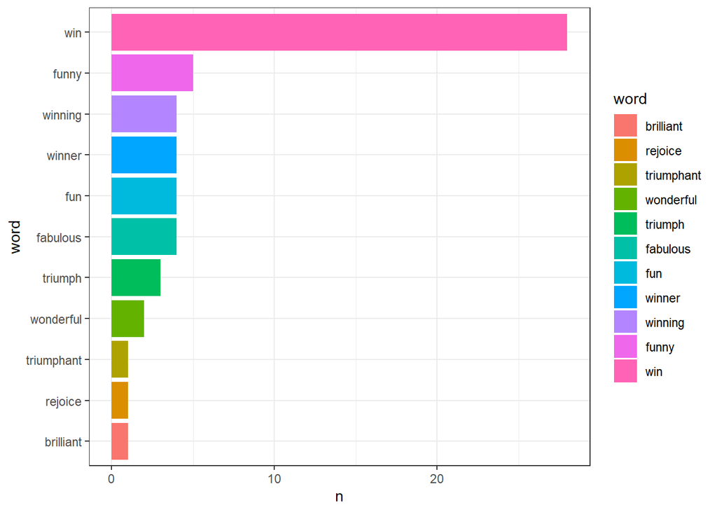

```r
got_afinn4_n <- got_afinn4 %>%
  count(word, sort = TRUE) %>%
  mutate(word = fct_reorder(factor(word), n))


pos_words <- ggplot(data = got_afinn4_n, aes(x = word, y = n, fill = word)) +
  geom_col() +
  coord_flip() +
  theme_bw()

pos_words
```

```r
ggsave(plot = pos_words, here("figures", "four_pos_words_GoT.png"), height = 8, width = 5)
```

The most frequent one is win, which appears almost 30 times, and hereafter other forms of winning, triumph, and so on. This could suggest that a central theme in the book is, as the title suggests, the struggle for power.

### Using the NRC lexicon for sentiment analysis

Using inner_join to combine the text with the NRC lexicon as above, where only words existing in both the text and the lexicon will stay.

```r
got_nrc <- got_stop %>%
  inner_join(get_sentiments("nrc"))
```

By using anti_join() we can see which words wont be in the analysis. A lot of the words that are most frequent, such as “Ser” and characternames, has been removed.

```r
got_exclude <- got_stop %>%
  anti_join(get_sentiments("nrc"))

got_exclude_n <- got_exclude %>%
  count(word, sort = TRUE)

head(got_exclude_n)
```

```
## # A tibble: 6 × 2
##   word       n
##   <chr>  <int>
## 1 ser     1023
## 2 jon      787
## 3 ned      743
## 4 tyrion   591
## 5 eyes     567
## 6 hand     567
```

##visualisations using NRC lexicon

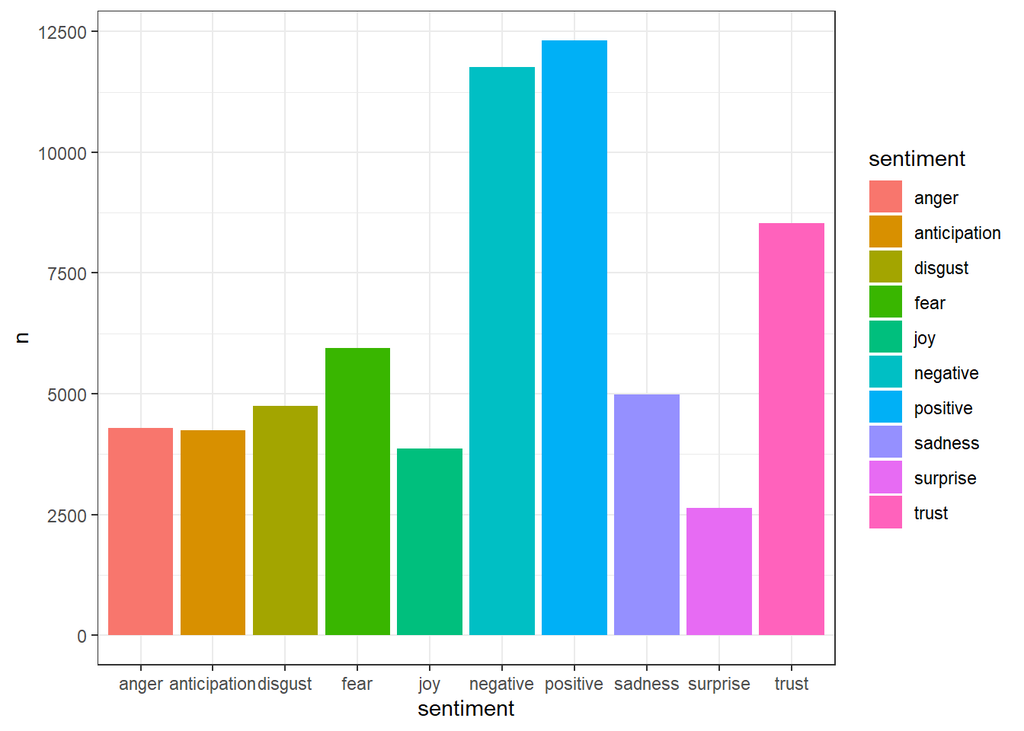

```r
got_nrc_n <- got_nrc %>%
  count(sentiment, sort = TRUE)

ggplot(data = got_nrc_n, aes(x = sentiment, y = n)) +
  geom_col(aes(fill = sentiment))+
  theme_bw()
```

Unlike the previous visualisation using AFINN, this one shows the book to be overall slightly more positive. To investigate further it’s possible to see which words are counted for each emotion:

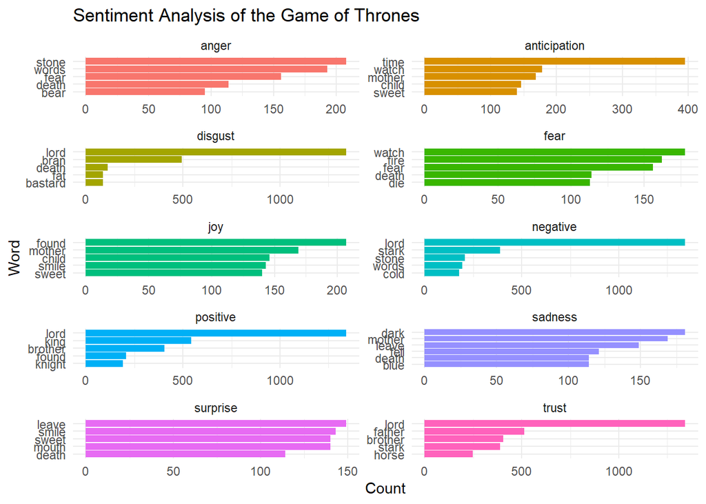

```r
got_nrc_n5 <- got_nrc %>%
  count(word,sentiment, sort = TRUE) %>%
  group_by(sentiment) %>%
  top_n(5) %>%
  ungroup()

got_nrc_gg <- ggplot(data = got_nrc_n5, aes(x = reorder(word,n), y = n, fill = sentiment)) +
  geom_col(show.legend = FALSE) +
  facet_wrap(~sentiment, ncol = 2, scales = "free") +
  coord_flip() +
  theme_minimal() +
  labs(x = "Word", y = "Count", title = "Sentiment Analysis of the Game of Thrones ")

got_nrc_gg
```

```r
ggsave(plot = got_nrc_gg,
       here("figures","got_nrc_sentiment.png"),
       height = 8,
       width = 5)
```

See portfolio for more on this graph.

### Credits:

I am closely following the “SentimentAnalysisIPCC”-tutorial.